# Single-cell B cell receptor repertoire analysis

CSAMA 2026 — Statistics and Computing in Genome Data Science

Katharina Imkeller

2026-05-28

## Learning objectives

By the end of this practical you will be able to:

1. Load and explore single-cell BCR sequencing data in **AIRR format**
2. Perform quality filtering appropriate for BCR repertoire analysis
3. Visualise **isotype composition** across patients and B cell populations
4. Infer **clonal groups** from CDR3 sequence similarity
5. Measure **somatic hypermutation (SHM)** frequency and interpret its biological meaning
6. Understand the concept of **clonal lineage trees** and visualize them

## Biological background

### B cells and the adaptive immune response

B cells are the antibody-producing cells of the adaptive immune system. Each B cell expresses a unique B cell receptor (BCR) that determines its antigen specificity. This specificity is generated during the B cell development in a process called **V(D)J recombination**. The receptor genes are assembled by randomly selecting and joining gene segments from three pools — Variable (V), Diversity (D), and Joining (J) — with additional nucleotides inserted at the junctions.

```
CDR3 region (hypervariable):

--|V segment|--|N|--|D segment|--|N|--|J segment|--
```

The resulting **CDR3 (Complementarity Determining Region 3)** is the most variable part of the BCR and the main determinant of antigen binding. Because the nucleotide additions at the junctions are random, each B cell carries a unique CDR3 — the “molecular fingerprint” of that cell and its descendants.

A complete BCR (and the secreted antibody) is a heterodimer: one **heavy chain** (encoded by IGH, assembled from V, D, and J segments) paired with one **light chain** (encoded by IGK or IGL, assembled from V and J segments only). Both chains contribute a CDR3, but the heavy-chain CDR3 is by far the more variable and is the primary focus of repertoire analysis.

### Clones, SHM, and class switching

When a B cell recognises its cognate antigen with sufficient affinity, it enters a **germinal centre** reaction in which two crucial processes occur:

- **Somatic hypermutation (SHM)**: The enzyme AID introduces point mutations throughout the variable region at a much higher rate than the background mutation rate. B cells with mutations that increase affinity to their cognate antigen are positively selected, leading to **affinity maturation**.
- **Class switch recombination (CSR)**: The constant region of the heavy chain is replaced, changing the **antibody isotype** from IgM to IgG, IgA, or IgE. The isotype determines the effector function of the secreted antibody.

B cells originating from the same VDJ rearrangement event are defined by the same V, D, J genes and highly similar CDR3 nucleotides. These B cell groups are called **clones** — they all descend from a single progenitor B cell and share the same antigen specificity.

### Single-cell BCR sequencing

10x Genomics’ V(D)J enrichment protocol captures full-length BCR sequences from single cells alongside their gene expression profiles. This allows us to:

- Link each BCR sequence to a specific cell’s transcriptional state (e.g., memory vs. naive B cell)
- Detect clonal relationships between cells
- Track BCR evolution (mutations, class switching) within clones

### Workflow overview

[output not shown]

For a workflow description on how to convert Cell Ranger output into AIRR standard format see: https://changeo.readthedocs.io/en/stable/examples/10x.html The conversion has already been performed on the data that is made available for the CSAMA lab.

### The AIRR Community standard

The **Adaptive Immune Receptor Repertoire (AIRR) Community** has defined a standard data format for representing BCR/TCR sequences. Each row in an AIRR TSV file represents one rearranged receptor sequence, with standardised column names such as:

| Column | Description |
| --- | --- |
| `sequence_id` | Unique identifier for this sequence |
| `cell_id` | Cell barcode |
| `locus` | IGH, IGK, IGL, TRA, TRB, etc. |
| `v_call`, `d_call`, `j_call` | Assigned V, D, J genes |
| `junction` | CDR3 nucleotide sequence |
| `junction_aa` | CDR3 amino acid sequence |
| `c_call` | Constant region gene (isotype) |
| `productive` | Whether the rearrangement is productive |
| `sequence_alignment` | V(D)J sequence aligned to germline |
| `germline_alignment` | Inferred germline sequence |

## The Immcantation framework

We will use the **Immcantation** suite of R packages, which provides a comprehensive toolkit for BCR/TCR repertoire analysis:

| Package | Purpose |
| --- | --- |
| `airr` | Read and write AIRR-format files |
| `alakazam` | Core repertoire analysis: V gene usage, diversity, clonal abundance |
| `shazam` | Mutation analysis, clonal threshold identification |
| `scoper` | Single-cell-aware clonal grouping |
| `dowser` | Phylogenetic lineage tree construction and visualisation |

## Setup

```r
library(airr)
library(alakazam)
library(shazam)
library(scoper)
library(dowser)
library(ggplot2)
library(dplyr)
library(tidyr)
library(patchwork)
library(stringr)
```

## The dataset

The data in this practical come from a single-cell multiomics experiment of **peripheral blood B cells** from three donors. Cells were captured using the 10x Genomics Chromium 5’ platform, which simultaneously captures gene expression (GEX) and V(D)J BCR sequences from the same cell.

**Preprocessing (already done):**

1. Raw reads were processed with **Cell Ranger** to assemble V(D)J contigs
2. Assembled contigs were aligned to IMGT germline references using **IgBLAST** via the Immcantation `AssignGenes.py` pipeline
3. The output was converted to AIRR TSV format using `MakeDb.py`

We therefore start from an AIRR TSV file and a metadata table containing cluster annotations derived from the gene expression data.

## 1. Data loading and exploration

### 1.1 Load BCR sequences

The `airr::read_rearrangement()` function reads an AIRR-format TSV and returns a data frame.

```r
receptors <- airr::read_rearrangement("../data/BCR_data_sequences_igblast_db-pass.tsv")
dim(receptors)
```

```
## [1] 3965   57
```

```r
# Column names
names(receptors)
```

```
##  [1] "sequence_id"        "sequence"           "rev_comp"
##  [4] "productive"         "v_call"             "d_call"
##  [7] "j_call"             "sequence_alignment" "germline_alignment"
## [10] "junction"           "junction_aa"        "v_cigar"
## [13] "d_cigar"            "j_cigar"            "stop_codon"
## [16] "vj_in_frame"        "locus"              "c_call"
## [19] "junction_length"    "np1_length"         "np2_length"
## [22] "v_sequence_start"   "v_sequence_end"     "v_germline_start"
## [25] "v_germline_end"     "d_sequence_start"   "d_sequence_end"
## [28] "d_germline_start"   "d_germline_end"     "j_sequence_start"
## [31] "j_sequence_end"     "j_germline_start"   "j_germline_end"
## [34] "v_score"            "v_identity"         "v_support"
## [37] "d_score"            "d_identity"         "d_support"
## [40] "j_score"            "j_identity"         "j_support"
## [43] "fwr1"               "fwr2"               "fwr3"
## [46] "fwr4"               "cdr1"               "cdr2"
## [49] "cdr3"               "cell_id"            "consensus_count"
## [52] "umi_count"          "v_call_10x"         "d_call_10x"
## [55] "j_call_10x"         "junction_10x"       "junction_10x_aa"
```

```r
# How many sequences per locus?
table(receptors$locus)
```

```
##
##  IGH  IGK  IGL
## 1913 1154  898
```

Each B cell contributes up to three sequences: one heavy chain (IGH) and one or two light chains (IGK or IGL). Note that a productive B cell should have exactly one functional heavy chain — cells with two heavy chain sequences are likely doublets or ather artifacts and need to be removed.

### 1.2 Load metadata

The metadata table contains one row per cell barcode. It was derived from the gene expression analysis (SingleCellExperiment) and includes cluster annotations computed based on the gene expression data. The `bcell_group` column assigns each cell to a broad B cell population (naive, memory, activated), while `bcell_subtype` provides finer-grained annotations based on GEX clustering.

```r
metadata <- read.csv("../data/metadata_complete_with_GEXcluster.csv")
dim(metadata)
```

```
## [1] 1819   17
```

```r
head(metadata[, c("Barcode", "sample_id", "bcell_group", "bcell_subtype")])
```

|  | Barcode | sample_id | bcell_group | bcell_subtype |
| --- | --- | --- | --- | --- |
| 1 | AAGGCACCAAGAATAC-1 | patient_A | memory | memory_1 |
| 2 | AATCGGACACGGTGTC-1 | patient_A | memory | memory_2 |
| 3 | ACAACCCAGGGGCATA-1 | patient_A | memory | memory_2 |
| 4 | ACTGCAGGTATGCTCC-1 | patient_A | memory | memory_2 |
| 5 | AGCCGAGCAAAGTGCA-1 | patient_A | activated | activated_1 |
| 6 | AGTGTAAAGCGTTGGT-1 | patient_A | memory | memory_2 |

```r
# B cell populations per patient
table(metadata$sample_id, metadata$bcell_group)
```

```
##
##             activated memory naive
##   patient_A         3     14     0
##   patient_B        22     46    17
##   patient_C       337    856   524
```

The `bcell_group` annotation assigns each cell to one of three broad B cell states:

- **naive**: IgM⁺IgD⁺ B cells that have not yet encountered antigen
- **memory**: antigen-experienced, long-lived B cells (often class-switched)
- **activated**: recently activated B cells undergoing differentiation

### 1.3 Merge BCR sequences with metadata

We join on `cell_id` (BCR data) and `Barcode` (metadata). Using `all.x = TRUE` retains all BCR sequences, with `NA` values in metadata columns for cells not found in the metadata.

```r
db <- merge(receptors, metadata,
            by.x = "cell_id",
            by.y = "Barcode",
            all.x = TRUE)

cat("Sequences before filtering:", nrow(db), "\n")
```

```
## Sequences before filtering: 3965
```

```r
cat("Sequences with metadata annotation:", sum(!is.na(db$sample_id)), "\n")
```

```
## Sequences with metadata annotation: 3627
```

```r
db <- db[!is.na(db$sample_id),]
```

**Exercise:** How many unique cells (cell barcodes) are in the merged dataset? How does this compare to the number of rows?

```r
# Your code here
```

## 2. Quality control and filtering

Repertoire data requires several filtering steps to remove technical artefacts and focus on biologically meaningful sequences.

### 2.1 Remove non-productive rearrangements

A rearrangement is **productive** if it is in-frame and contains no stop codons — only productive rearrangements encode a functional receptor protein.

```r
cat("Non-productive sequences:", sum(!db$productive), "\n")
```

```
## Non-productive sequences: 1
```

```r
db <- db[db$productive, ]
cat("After productive filter:", nrow(db), "sequences\n")
```

```
## After productive filter: 3626 sequences
```

### 2.2 Remove cells with multiple heavy chains

Each B cell should have exactly one productive heavy chain. Cells with two or more heavy chain sequences are likely **doublets** (two cells captured together) or sequencing artefacts, and should be excluded.

```r
# Find cells with multiple heavy chains
heavy_counts <- db %>%
  filter(locus == "IGH") %>%
  count(cell_id, name = "n_heavy")

multi_heavy_cells <- heavy_counts$cell_id[heavy_counts$n_heavy > 1]
cat("Cells with multiple heavy chains:", length(multi_heavy_cells), "\n")
```

```
## Cells with multiple heavy chains: 29
```

```r
db <- db[!db$cell_id %in% multi_heavy_cells, ]
cat("After multi-heavy filter:", nrow(db), "sequences\n")
```

```
## After multi-heavy filter: 3515 sequences
```

### 2.3 Filtering summary

**Exercise:** How many unique cells (cell barcodes) remain in the merged dataset? How many sequences for each locus (IGH, IGK, IGL)?

```r
# Your code here
```

For the downstream analyses focused on heavy chains, we work with the IGH subset:

```r
db_heavy <- db[db$locus == "IGH", ]
cat("Heavy chain sequences:", nrow(db_heavy), "\n")
```

```
## Heavy chain sequences: 1691
```

## 3. Isotype composition

The **isotype** (IgM, IgD, IgG, IgA, IgE) of the BCR heavy chain reflects the cell’s history of class switch recombination. IgM and IgD are the default isotypes of naive B cells; IgG, IgA, and IgE require germinal centre reactions.

### 3.1 Create isotype family annotation

```r
db_heavy <- db_heavy %>%
  mutate(isotype = case_when(
    str_starts(c_call, "IGHM") ~ "IgM",
    str_starts(c_call, "IGHD") ~ "IgD",
    str_starts(c_call, "IGHG") ~ "IgG",
    str_starts(c_call, "IGHA") ~ "IgA",
    str_starts(c_call, "IGHE") ~ "IgE",
    TRUE ~ "Unknown"
  ))

table(db_heavy$isotype)
```

```
##
##     IgA     IgD     IgG     IgM Unknown
##     168      97     505     916       5
```

### 3.2 Isotype distribution per patient

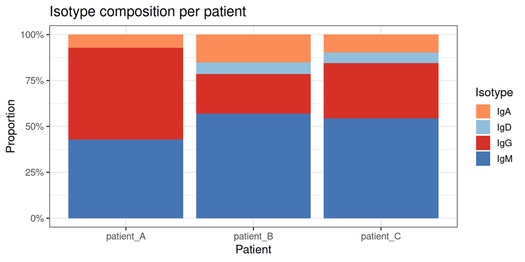

```r
isotype_counts <- db_heavy %>%
  filter(isotype != "Unknown")

isotype_cols <- c(IgM = "#4575b4", IgD = "#91bfdb", IgG = "#d73027",
                  IgA = "#fc8d59", IgE = "#fee090")

ggplot(isotype_counts, aes(x = sample_id, fill = isotype)) +
  geom_bar(position = "fill") +
  scale_fill_manual(values = isotype_cols) +
  scale_y_continuous(labels = scales::percent) +
  labs(x = "Patient", y = "Proportion", fill = "Isotype",
       title = "Isotype composition per patient") +
  theme_bw(base_size = 13)
```

### 3.3 Subclass-level resolution

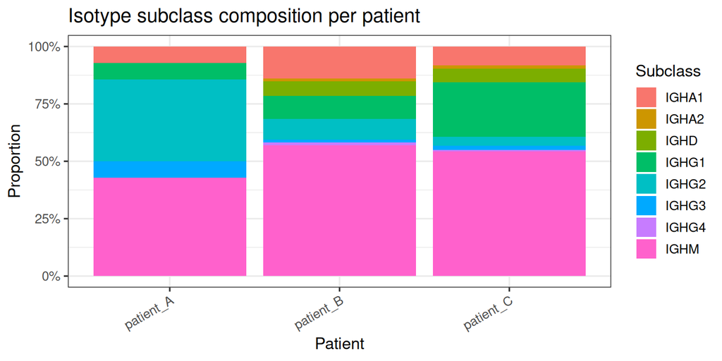

```r
subclass_counts <- db_heavy %>%
  filter(!is.na(c_call), c_call != "")

ggplot(subclass_counts, aes(x = sample_id, fill = c_call)) +
  geom_bar(position = "fill") +
  scale_y_continuous(labels = scales::percent) +
  labs(x = "Patient", y = "Proportion", fill = "Subclass",
       title = "Isotype subclass composition per patient") +
  theme_bw(base_size = 13) +
  theme(axis.text.x = element_text(angle = 30, hjust = 1))
```

### 3.4 Isotype composition by B cell group

One advantage of single-cell data is the ability to link BCR properties to cell state annotations from the gene expression analysis.

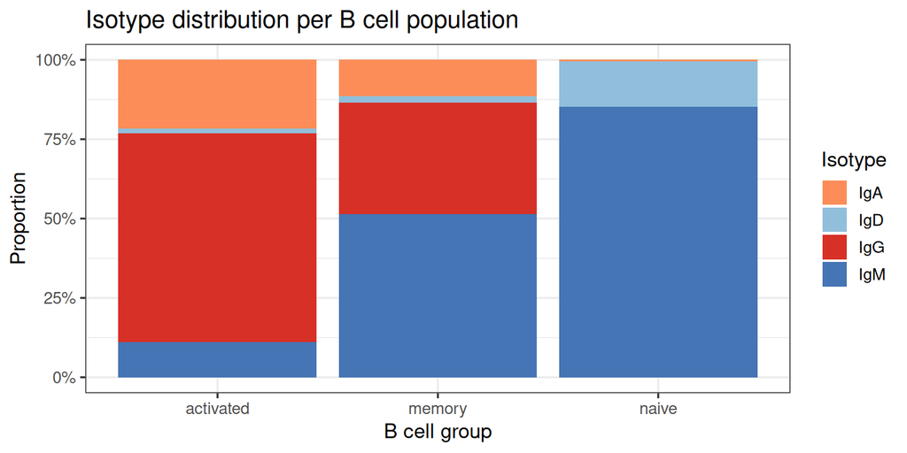

```r
iso_group <- db_heavy %>%
  filter(isotype != "Unknown")

ggplot(iso_group, aes(x = bcell_group, fill = isotype)) +
  geom_bar(position = "fill") +
  scale_fill_manual(values = isotype_cols) +
  scale_y_continuous(labels = scales::percent) +
  labs(x = "B cell group", y = "Proportion", fill = "Isotype",
       title = "Isotype distribution per B cell population") +
  theme_bw(base_size = 13)
```

> **Discussion:** Based on the isotype distribution, which B cell population has undergone the most class switching? Does this match your biological expectation?

**Exercise 2:** Plot the isotype subclass composition separately for IgG-positive cells within each B cell group. Are certain IgG subclasses enriched in particular populations?

```r
# Your code here
# Hint: filter to IgG subclasses using str_starts(c_call, "IGHG"), then group by bcell_group
```

## 4. V gene usage

The V gene determines much of the antigen-binding surface shape. Examining V gene usage frequencies reveals biases in the pre-immune repertoire and potential antigen-driven selection.

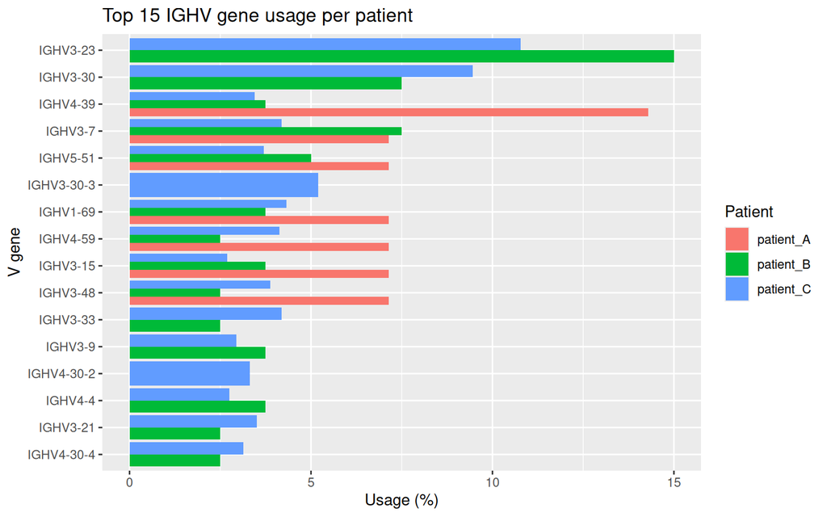

```r
# countGenes from alakazam calculates gene segment usage frequencies (independent of alleles)
v_usage <- countGenes(db_heavy, gene = "v_call", groups = "sample_id",
                      mode = "gene")

# Top 15 most used V genes overall
top_v <- v_usage %>%
  group_by(gene) %>%
  summarise(total = sum(seq_count), .groups = "drop") %>%
  slice_max(total, n = 15) %>%
  pull(gene)

v_usage %>%
  filter(gene %in% top_v) %>%
  group_by(sample_id) %>%
  dplyr::mutate(pct = 100 * seq_freq) %>%
  ggplot(aes(x = reorder(gene, pct), y = pct, fill = sample_id)) +
  geom_col(position = "dodge") +
  coord_flip() +
  labs(x = "V gene", y = "Usage (%)", fill = "Patient",
       title = "Top 15 IGHV gene usage per patient")
```

## 5. Clonal inference

### 5.1 What is a clone?

Two B cells belong to the same **clone** if they derived from the same ancestor B cell and therefore share: - The same V and J gene assignments - The same CDR3 length - Highly similar CDR3 sequences (allowing for SHM-introduced mutations)

The standard approach (Immcantation) is hierarchical agglomerative clustering on CDR3 Hamming distances, with a threshold determined from the data.

### 5.2 Estimate the clonal threshold

`shazam::distToNearest()` computes, for each heavy chain sequence, the **nearest-neighbour distance** (normalised Hamming distance) to the most similar sequence *within the same V/J gene and CDR3 length group*.

The resulting distance distribution typically shows two populations: - **Clonally related sequences** (within-clone): distances close to 0 - **Unrelated sequences** (between clones): distances around 0.2–0.6

The valley between these two populations is the optimal threshold.

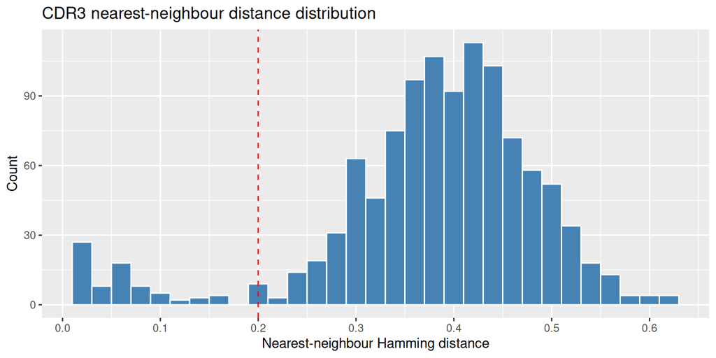

```r
# Use one patient for threshold estimation (computationally lighter)
# Use cross = "sample_id" to also estimate between-donor (non-clonal) distances
dist_nn <- distToNearest(
  filter(db_heavy, !is.na(junction), nchar(junction) > 0),
  cellIdColumn = "cell_id",
  nproc = 1
)

ggplot(filter(dist_nn, !is.na(dist_nearest)),
       aes(x = dist_nearest)) +
  geom_histogram(binwidth = 0.02, fill = "steelblue", color = "white") +
  geom_vline(xintercept = 0.2, linetype = "dashed", color = "red") +
  scale_x_continuous(breaks = seq(0, 1, 0.1)) +
  labs(x = "Nearest-neighbour Hamming distance",
       y = "Count",
       title = "CDR3 nearest-neighbour distance distribution")
```

### 5.3 Find the optimal threshold

Using **cross-subject distances** (distances between sequences from different donors, which *cannot* be clonally related) as a negative control greatly improves threshold accuracy.

```r
dist_cross <- distToNearest(
  filter(db_heavy, !is.na(junction), nchar(junction) > 0),
  nproc  = 1,
  cross  = "sample_id",
  cellIdColumn = "cell_id"
)
```

```r
threshold_result <- shazam::findThreshold(
  dist_nn$dist_nearest
)

threshold_val <- threshold_result@threshold
cat("Estimated clonal threshold:", round(threshold_val, 3), "\n")
```

```
## Estimated clonal threshold: 0.135
```

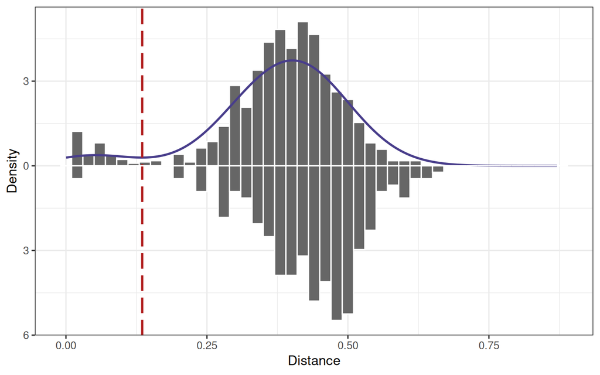

```r
plot(threshold_result, binwidth = 0.02,
     cross = dist_cross$cross_dist_nearest,
     silent = TRUE) +
  theme_bw(base_size = 13)
```

The dashed vertical line marks the chosen threshold. Sequences within a clone should have CDR3 distances below this value.

### 5.4 Define clonal groups

`scoper::hierarchicalClones()` performs the hierarchical clustering using the estimated threshold. Setting `fields = "sample_id"` ensures that clones are defined within each donor separately (cross-donor clones are biologically implausible).

```r
clones <- hierarchicalClones(
  filter(db_heavy, !is.na(junction), nchar(junction) > 0),
  cell_id   = "cell_id",
  threshold = threshold_val,
  only_heavy  = TRUE,
  split_light = FALSE,
  summarize_clones = FALSE,
  fields = "sample_id"
)

cat("Sequences assigned to clones:", nrow(clones), "\n")
```

```
## Sequences assigned to clones: 1691
```

```r
cat("Unique clones:", n_distinct(clones$clone_id), "\n")
```

```
## Unique clones: 1610
```

### 5.5 Clone size distribution

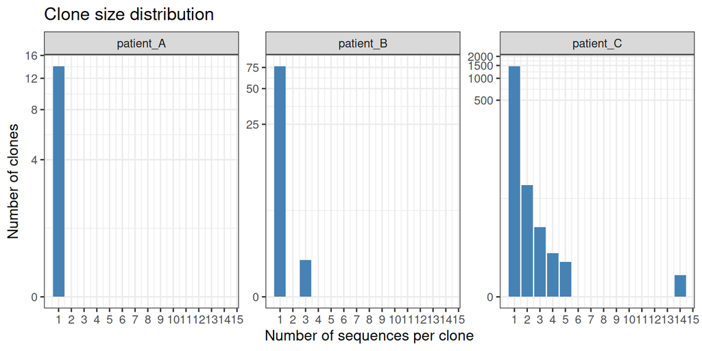

```r
clone_sizes <- countClones(clones, groups = "sample_id")

ggplot(clone_sizes, aes(x = seq_count)) +
  geom_bar(fill = "steelblue") +
  facet_wrap(~sample_id, scales = "free_y") +
  scale_x_continuous(breaks = 1:15) +
  scale_y_continuous(trans = "log1p") +
  labs(x = "Number of sequences per clone", y = "Number of clones",
       title = "Clone size distribution") +
  theme_bw(base_size = 12)
```

> **Discussion:** What fraction of clones are singletons (size = 1)? What does this tell us about the depth of sampling and the extent of clonal expansion in these donors?

**Exercise 3:** Calculate the fraction of cells that belong to expanded clones (clone size ≥ 2) in each patient. How does this relate to the `bcell_group` composition?

```r
# Your code here
```

## 6. Somatic hypermutation

### 6.1 Background

Somatic hypermutation introduces mutations into V gene sequences during the germinal centre reaction. By comparing the observed sequence to the inferred germline (unmutated ancestor), we can estimate the mutation frequency — a proxy for the extent of affinity maturation.

`shazam::observedMutations()` computes mutation frequencies by comparing `sequence_alignment` to `germline_alignment` within defined regions of the V gene.

> **Note:** In this practical we use the germline sequences already present in the data (from IgBLAST). In a production analysis you would typically re-construct germlines using `dowser::createGermlines()` with IMGT reference databases, which performs D-region masking to avoid incorrectly counting D-segment nucleotides as V-gene mutations.

### 6.2 Overall V-gene mutation frequency

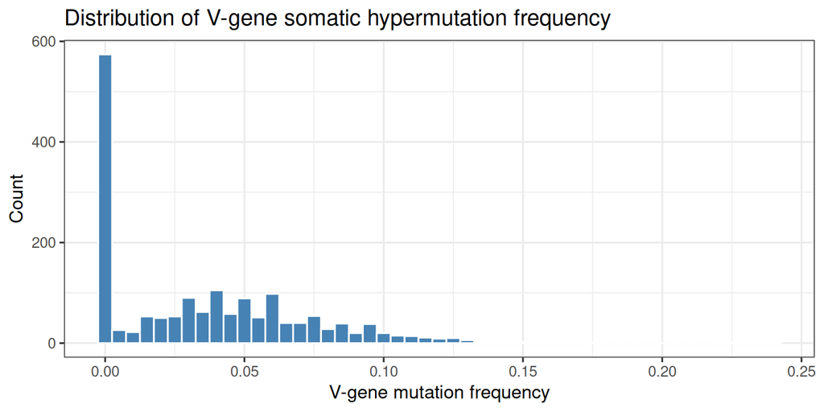

```r
data_mut <- shazam::observedMutations(
  clones,
  sequenceColumn  = "sequence_alignment",
  germlineColumn  = "germline_alignment",
  regionDefinition = IMGT_V,
  frequency = TRUE,
  combine   = TRUE,
  nproc     = 1
)

ggplot(data_mut, aes(x = mu_freq)) +
  geom_histogram(binwidth = 0.005, fill = "steelblue", color = "white") +
  labs(x = "V-gene mutation frequency", y = "Count",
       title = "Distribution of V-gene somatic hypermutation frequency") +
  theme_bw(base_size = 13)
```

### 6.3 SHM frequency by isotype

IgM sequences should show little to no SHM (they have not undergone germinal centre reactions), while IgG and IgA should show higher mutation frequencies.

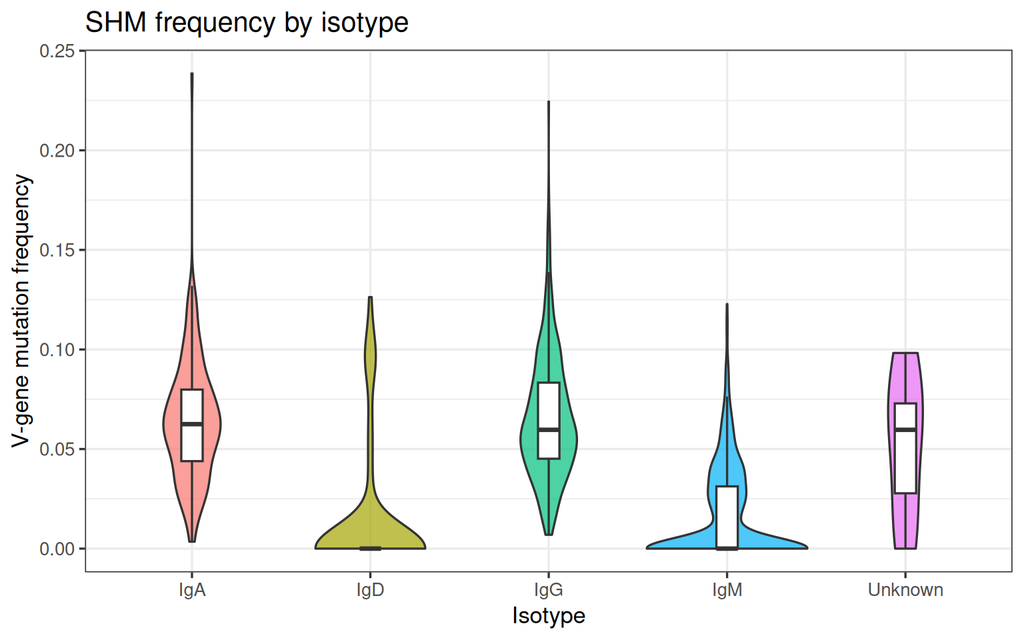

```r
data_mut %>%
ggplot(aes(x = isotype, y = mu_freq, fill = isotype)) +
  geom_violin(alpha = 0.7, trim = TRUE) +
  geom_boxplot(width = 0.12, outlier.shape = NA, fill = "white") +
  labs(x = "Isotype", y = "V-gene mutation frequency",
       title = "SHM frequency by isotype") +
  theme_bw(base_size = 13) +
  theme(legend.position = "none")
```

### 6.4 SHM frequency by B cell population

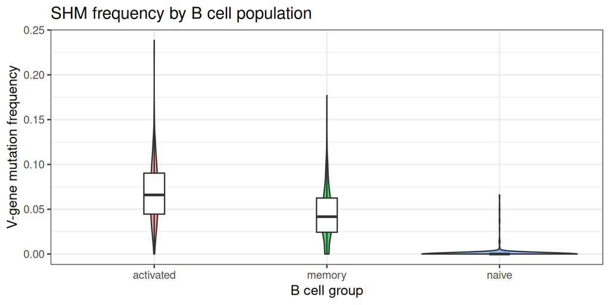

```r
ggplot(filter(data_mut, !is.na(bcell_group)),
       aes(x = bcell_group, y = mu_freq, fill = bcell_group)) +
  geom_violin(alpha = 0.7, trim = TRUE) +
  geom_boxplot(width = 0.12, outlier.shape = NA, fill = "white") +
  labs(x = "B cell group", y = "V-gene mutation frequency",
       title = "SHM frequency by B cell population") +
  theme_bw(base_size = 13) +
  theme(legend.position = "none")
```

> **Discussion:** Which B cell population shows the highest mutation frequencies? Does this fit the expected biology?

### 6.5 CDR vs framework region mutation bias

During affinity maturation, selection pressure concentrates mutations in the antigen-contacting CDR loops (CDR1, CDR2, CDR3) relative to the framework regions (FWR1–4). A high CDR:FWR mutation ratio is a signature of antigen-driven selection.

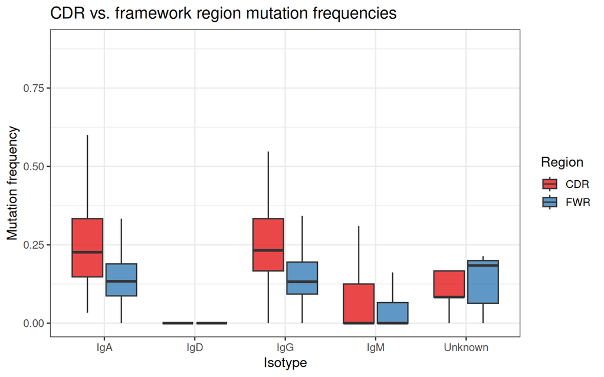

```r
# combine=FALSE keeps per-region columns (CDR1, CDR2, FWR1–3)
# each split into replacement (_r) and silent (_s) mutation frequencies
data_mut_reg <- shazam::observedMutations(
  clones,
  sequenceColumn   = "sequence_alignment",
  germlineColumn   = "germline_alignment",
  regionDefinition = IMGT_V_BY_REGIONS,
  frequency = TRUE,
  combine   = FALSE,
  nproc     = 1
)

# Sum replacement mutation frequencies across all CDR / FWR columns
cdr_cols <- grep("^mu_freq_cdr", names(data_mut_reg), value = TRUE)
fwr_cols <- grep("^mu_freq_fwr", names(data_mut_reg), value = TRUE)

data_mut_reg <- data_mut_reg %>%
  mutate(
    cdr_freq = rowSums(across(all_of(cdr_cols)), na.rm = TRUE),
    fwr_freq = rowSums(across(all_of(fwr_cols)), na.rm = TRUE)
  )

data_mut_long <- data_mut_reg %>%
  select(sequence_id, isotype, bcell_group, cdr_freq, fwr_freq) %>%
  tidyr::pivot_longer(c(cdr_freq, fwr_freq),
                      names_to = "region", values_to = "mu_freq") %>%
  mutate(region = recode(region, cdr_freq = "CDR", fwr_freq = "FWR"))

ggplot(data_mut_long, aes(x = isotype, y = mu_freq, fill = region)) +
  geom_boxplot(outlier.shape = NA, alpha = 0.8) +
  scale_fill_manual(values = c(CDR = "#e41a1c", FWR = "#377eb8")) +
  labs(x = "Isotype", y = "Mutation frequency", fill = "Region",
       title = "CDR vs. framework region mutation frequencies") +
  theme_bw(base_size = 13)
```

**Exercise 4:** Calculate the CDR:FWR mutation frequency ratio for each sequence and compare it between IgG and IgM B cells. Which isotype shows stronger evidence of antigen selection?

```r
# Your code here
# Hint: use data_mut_reg which already has cdr_freq and fwr_freq columns
# Calculate ratio: cdr_freq / (fwr_freq + 1e-9)  to avoid division by zero
```

## 7. Linking BCR properties to GEX clusters

A key advantage of single-cell data is the ability to overlay BCR properties onto the GEX-based UMAP embedding. Here we demonstrate this conceptually — in a full analysis you would load the Seurat or SingleCellExperiment object.

### 7.1 SHM frequency per B cell subtype

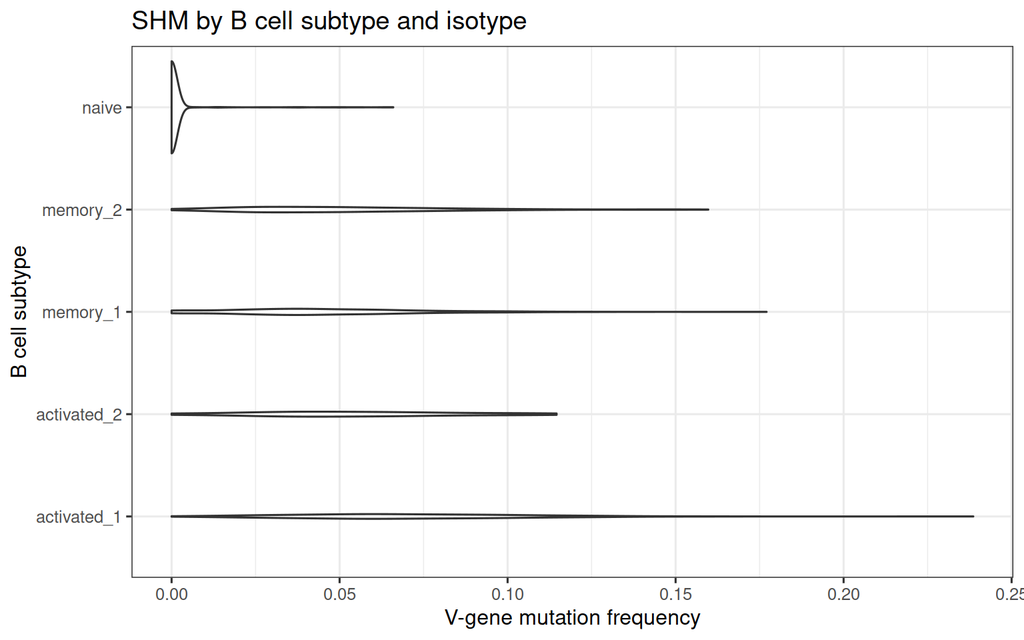

```r
data_mut %>%
  group_by(bcell_subtype, isotype) %>%
  ggplot(aes(x = bcell_subtype, y = mu_freq)) +
  geom_violin(position = "dodge") +
  coord_flip() +
  labs(x = "B cell subtype", y = "V-gene mutation frequency",
       title = "SHM by B cell subtype and isotype") +
  theme_bw(base_size = 12)
```

### 7.2 Clonal sharing between B cell populations

Are clones shared between B cell groups (e.g., does the same clone have naive and memory members)?

```r
clonal_groups <- clones %>%
  filter(!is.na(clone_id), !is.na(bcell_group)) %>%
  group_by(clone_id) %>%
  summarise(
    n_cells   = n(),
    groups_present = paste(sort(unique(bcell_group)), collapse = "/"),
    .groups = "drop"
  ) %>%
  count(groups_present, name = "n_clones") %>%
  arrange(desc(n_clones))

print(clonal_groups)
```

```
## # A tibble: 6 × 2
##   groups_present         n_clones
##   <chr>                     <int>
## 1 memory                      773
## 2 naive                       520
## 3 activated                   306
## 4 activated/memory              7
## 5 memory/naive                  3
## 6 activated/memory/naive        1
```

## 8. Clonal lineage trees

Phylogenetic trees of BCR sequences within a clone reveal the evolutionary history of affinity maturation — from the unmutated germinal centre founder to the most mutated descendants.

### 8.1 Concept

Within a clone, sequences are related by shared mutations. By building a maximum parsimony or maximum likelihood tree rooted at the inferred germline sequence, we can reconstruct the mutational trajectory of the clone.

The **dowser** package provides: - `formatClones()`: prepare clone data for tree building - `getTrees()`: build phylogenetic trees (using phangorn/ML methods) - `plotTrees()`: visualise trees with trait annotations

### 8.2 Germline reconstruction

For robust tree building, the germline sequence need to be identical for all members of a clone to avoid alignment artefacts. This requires IMGT germline databases, which must be downloaded separately (not part of this practical):

```r
# Run only if IMGT references are available
# references <- readIMGT(dir = "/path/to/imgt/human/vdj/")
# clones_with_gl <- createGermlines(clones, references, fields = "sample_id")
```

For this practical we illustrate the tree-building workflow using the existing germline sequences. One important preparation step is described below.

### 8.3 Build trees for selected clones

`formatClones()` requires all sequences within a clone to carry the **same** germline sequence. IgBLAST assigns germlines independently to each sequence and can produce slightly different assignments within a clone. The proper solution is `createGermlines()`, which reconstructs a single consensus germline per clone using IMGT references. As a practical workaround when IMGT references are unavailable, we standardise by taking the most frequently assigned germline within each clone.

```r
# Select well-represented clones (≥ 5 sequences) for tree building
large_clones <- clones %>%
  filter(!is.na(clone_id), !is.na(germline_alignment)) %>%
  count(clone_id) %>%
  filter(n >= 4) %>%
  pull(clone_id)


cat("Clones with ≥ 4 sequences:", length(large_clones), "\n")

clones_tree_input <- clones %>%
  filter(clone_id %in% large_clones,
         !is.na(isotype),
         !is.na(germline_alignment))

# Standardise germlines within each clone (workaround needed because of missing germline reconstruction step with IMGT reference)
# Better approach (not feasible in this tutorial: createGermlines(clones, references, fields = "sample_id")
 clones_tree_input <- clones_tree_input %>%
   group_by(clone_id) %>%
   mutate(germline_alignment = {
     tbl <- table(germline_alignment)
     # use most common germline sequence
     names(tbl)[which.max(tbl)]
   }) %>%
   ungroup()

clone_objs <- formatClones(
  clones_tree_input,
  traits  = c("isotype", "bcell_group", "sample_id"),
  minseq  = 4,
  nproc   = 1,
  germ    = "germline_alignment"
)

trees <- getTrees(clone_objs, build = "pml", nproc = 1)
```

### 8.4 Visualise trees

```r
# Scale branches by number of mutations
trees_scaled <- scaleBranches(trees, edge_type = "mutations")

# Plot first few trees coloured by isotype
plotTrees(trees_scaled,
          tips     = "isotype",
          tipsize  = "collapse_count")
```

[output not shown]

### Further reading

- [Immcantation documentation](https://immcantation.readthedocs.io)
- [Gupta et al. (2015) — Change-O: toolkit for BCR repertoire analysis](https://doi.org/10.1093/bioinformatics/btv359)
- [Heiden et al. (2018) — AIRR community MiAIRR standards](https://doi.org/10.3389/fimmu.2017.01102)
- [Kleinstein lab tutorials](https://kleinstein.bitbucket.io/tutorials/)